# Lab2

Skyler Moomey

9/1/2020

# Tasks

## Task 1

```r
getwd()
```

```
## [1] "C:/Users/skyle/Documents/Statistics/Laboratories/Lab2"
```

## Task 2

```r
dird = "C:\\Users\\skyle\\Documents\\Statistics\\Laboratories\\Lab2\\"
#my function to read data courtesy of Dr. Stewart
myread=function(csv){
  fl=paste(dird,csv,sep="")
  read.table(fl,header=TRUE,sep=",")
}
epagas_data=myread("EPAGAS.csv")
head(epagas_data)
```

```
##   ï..MPG
## 1   36.3
## 2   41.0
## 3   36.9
## 4   37.1
## 5   44.9
## 6   36.8
```

## Task 3

```r
mpg <- epagas_data$ï..MPG
z = (mpg - mean(mpg))/sd(mpg)
mean_z = mean(z)
sd_z = sd(z)
```

The mean z score is: 1.058709210^{-16}, which is approximately 0, while the standard deviation is 1

The first line corresponds to the only definite outlier (RED), and the second corresponds to the 3 possible outliers (BLUE).

```r
outliers <- mpg[abs(z) > 3]
outliers
```

```
## [1] 44.9
```

```r
possible_outliers <- mpg[abs(z) > 2 & abs(z) <= 3]
possible_outliers
```

```
## [1] 30.0 42.1 31.8
```

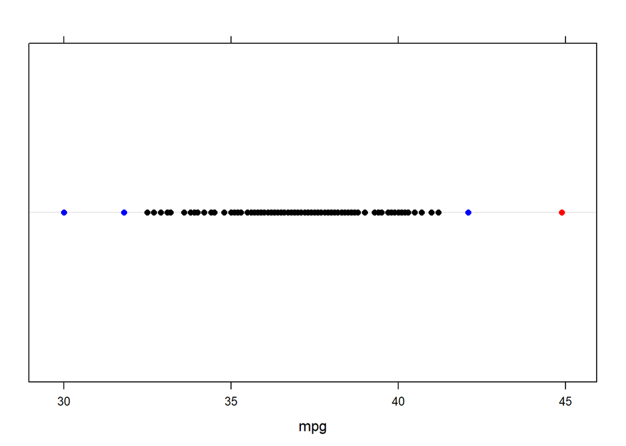

```r
#Thanks again Dr. Stewart
mycol = ifelse(abs(z)>3, "Red",
        ifelse(abs(z)>=2 &abs(z)<=3,"Blue", "Black"))

library(lattice)
dotplot(mpg,col=mycol)
```

## Task 4

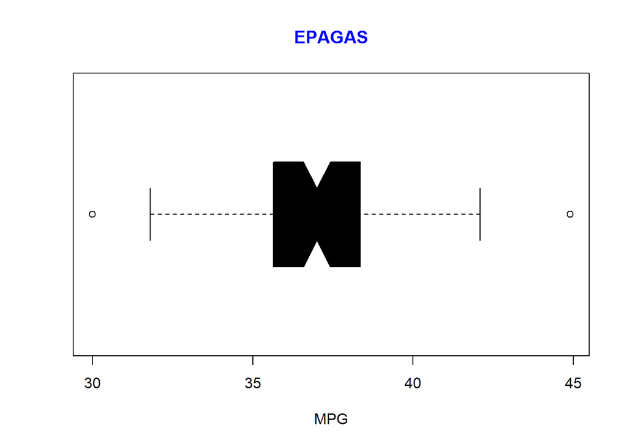

```r
boxplot(mpg,xlab="MPG",col="Black",notch=TRUE, horizontal = TRUE)
title(main = "EPAGAS", col.main = "Blue")
```

```r
length(mpg)
```

```
## [1] 100
```

```r
length(mpg[abs(z) <= 3])
```

```
## [1] 99
```

```r
#function taken from https://www.tutorialspoint.com/r/r_mean_median_mode.htm
getmode <- function(v) {
   uniqv <- unique(v)
   uniqv[which.max(tabulate(match(v, uniqv)))]
}

length(epagas_data$ï..MPG)
```

```
## [1] 100
```

```r
length(epagas_data$ï..MPG[abs(z) <= 2])
```

```
## [1] 96
```

```r
#proportion of data within 2 standard deviations is 96/100
```

According to Chebyshev, there should be $1 - \frac{1}{k^2} = 1 - \frac{1}{2^2} = 1 - \frac{1}{4} = \frac{3}{4}$ of the data within two standard deviations of the mean. In reality, 96% of the data is within two standard deviations of the mean.

Chebyshev’s theorem guarantees that a minimum of three quarters of the data will be within two standard deviations, which agrees with our findings.

The empirical rule, by contrast, estimates that about 95% of the data points will be within two standard deviations, assuming the data is uni-modal and relatively symmetric. The only mode of our data is 37. As you can see in our 2-dimensional dotplot, the data is also relatively symmetric, so the empirical rule can be used. It is much more accurate in this case than Chebyshev’s Theorem.

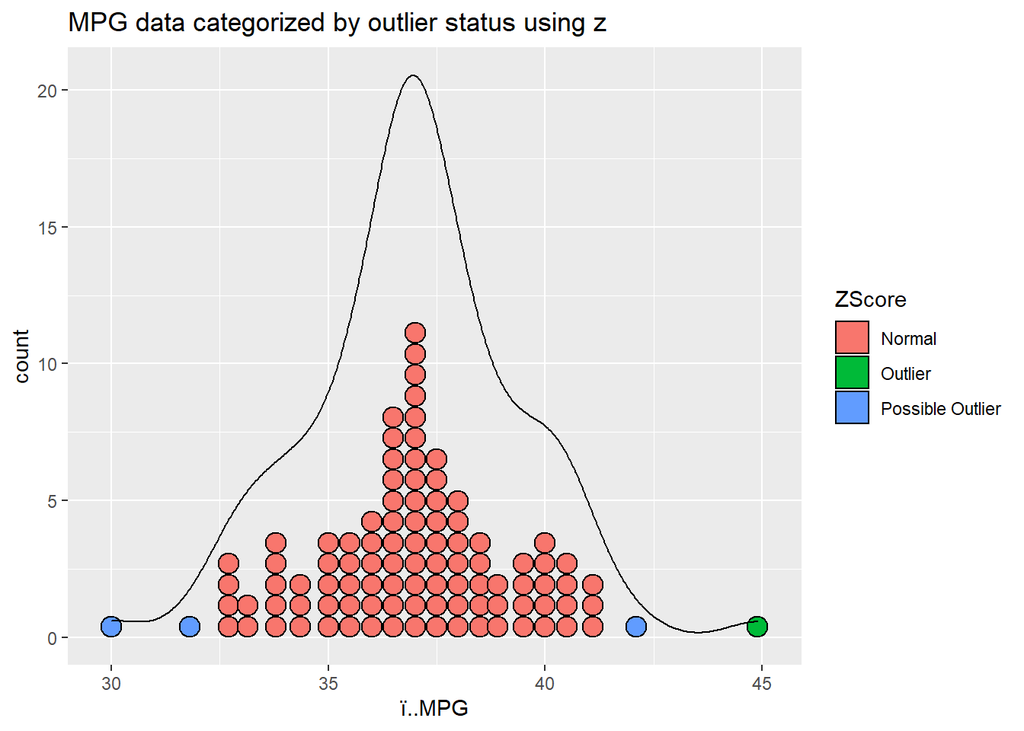

```r
mn <- mean(epagas_data$ï..MPG)
sdd <- sd(epagas_data$ï..MPG)
epagas_data <- epagas_data %>% mutate( z = (ï..MPG-mn)/sdd,
                       ZScore = ifelse(abs(z)> 3, "Outlier",
                                    ifelse(abs(z)>=2 & abs(z)<=3,
                                           "Possible Outlier", "Normal")))
g <- ggplot(epagas_data, aes(x = ï..MPG)) + geom_dotplot(aes(fill = ZScore),binwidth = 1/5*sdd)
g <- g + geom_density(aes(y = ..count..))
g <- g + labs(title = "MPG data categorized by outlier status using z")
g
```